# Diamond Price Estimation

Süheyla Şeker

12/09/2020

In this assignment the `diamonds` data set in ggplot2 package is used.First, the relationship between different variables and diamond prices and other data visualizations were made, and a preliminary impression was formed on behalf of the variables needed to build the model. The CART model was created using some variables in the data, and then the previous model was improved with components obtained by PCA. The `price` column is used as the response variable and other columns (except `diamond_id`) are used as predictors.

# 1 Loading Packages

```r
library(tidyverse)
library(dplyr)
library(ggplot2)
library(broom)
library(rpart)
library(rpart.plot)
library(rattle)
library(cowplot)
```

# 2 Data Processing

Train and test data are created using `diamonds` data frame.

```r
set.seed(503)

diamonds_test <- diamonds %>% mutate(diamond_id = row_number()) %>%
  group_by(cut, color, clarity) %>% sample_frac(0.2) %>% ungroup()

diamonds_train <- anti_join(diamonds %>% mutate(diamond_id = row_number()),
                            diamonds_test, by = "diamond_id")

diamonds_train<-diamonds_train%>% select(-diamond_id)
diamonds_test<-diamonds_test%>% select(-diamond_id)
```

# 3 Explanatory Data Analysis

A custom color group is created to use in data visualization.

```r
custom.col <- c("#000000", "#58D68D", "#8E44AD", "#FCFF33",
                "#F14CDA", "#0CC3F6", "#E53A07", "#F39C12")
```

## 3.1 Number of Diamonds for Different Cuts and Clarities

- The number of diamonds with different cut and clarities in data is visualized below.

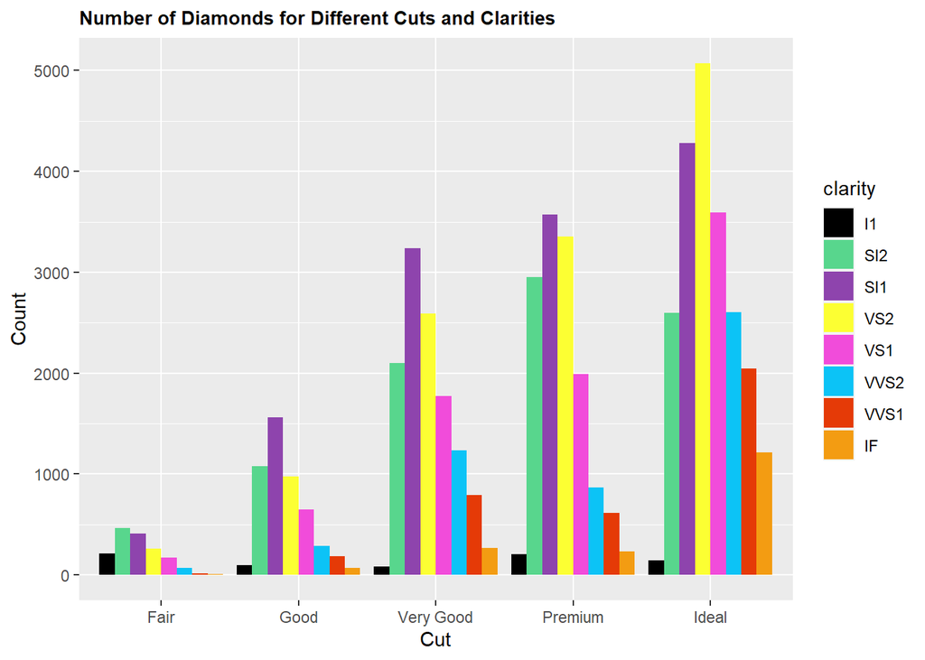

```r
ggplot(diamonds, aes(x = cut, fill = clarity)) +
  geom_bar(position = "dodge")+theme(plot.title = element_text(size=10,face="bold"))+scale_fill_manual(values =custom.col)+labs(x="Cut", y="Count",title="Number of Diamonds for Different Cuts and Clarities")
```

## 3.2 The Distribution of Price by Clarity

- The distribution of price by clarity of diamonds is visualized below.

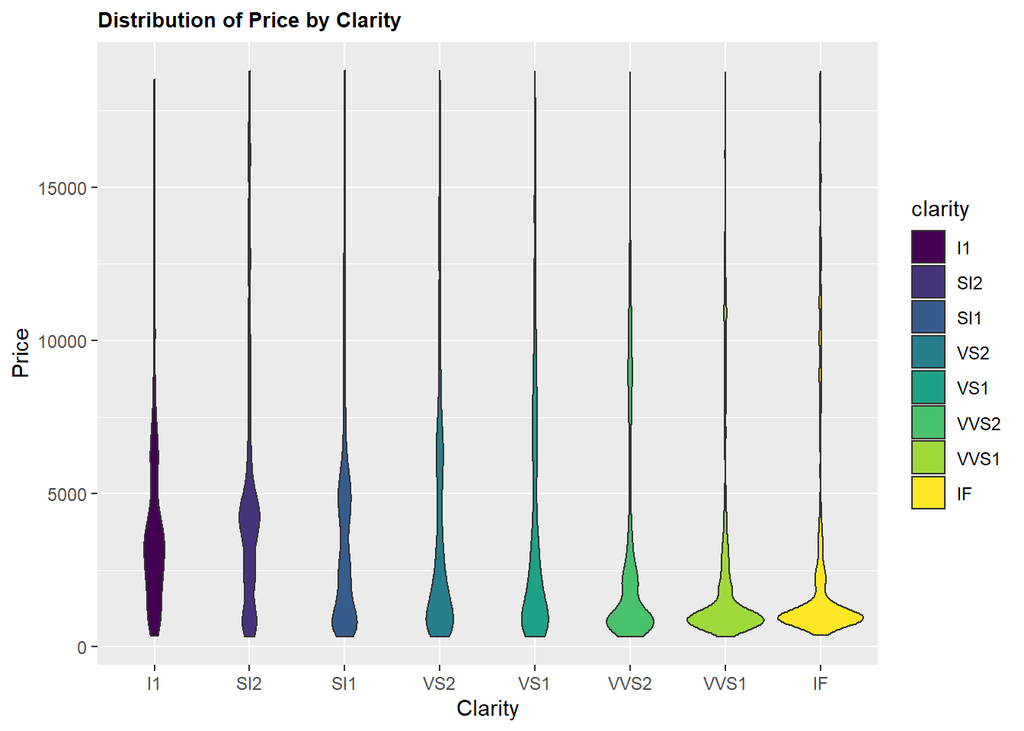

```r
diamonds %>%
  ggplot(aes(x = clarity, y = price)) +
  geom_violin(aes(fill = clarity))+labs(x="Clarity", y="Price",title="Distribution of Price by Clarity")+theme(plot.title = element_text(size=10,face="bold"))
```

## 3.3 The Relation Between Carat, Depth, Table, Cut with Price

- The relation between price and other variables are visualized below.

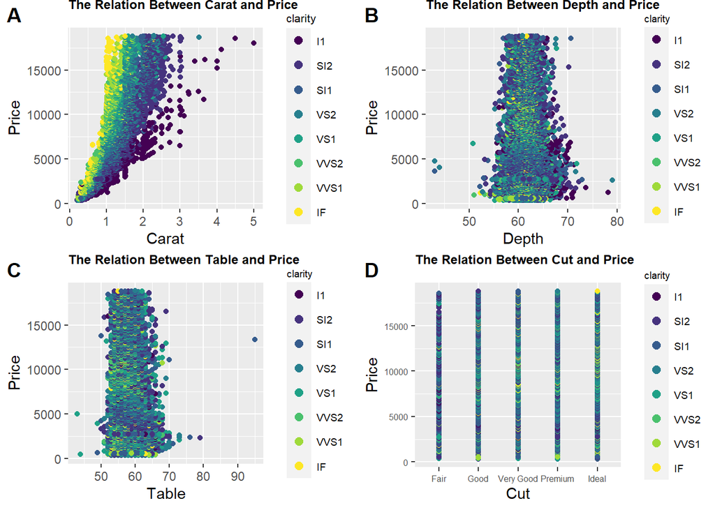

```r
plota<-ggplot(diamonds, aes(x=carat, y=price, color=clarity)) + geom_point()+labs(x="Carat", y="Price",title="The Relation Between Carat and Price")+theme(plot.title = element_text(size=9,face="bold",vjust=4),legend.title = element_text(size = 8),legend.text = element_text(size = 7)) +
        guides(shape = guide_legend(override.aes = list(size = 1)),
               color = guide_legend(override.aes = list(size =2.5)))

plotb<-ggplot(diamonds, aes(x=depth, y=price, color=clarity)) + geom_point()+labs(x="Depth", y="Price",title="The Relation Between Depth and Price")+theme(plot.title = element_text(size=9,face="bold",vjust=4),legend.title = element_text(size = 7),legend.text = element_text(size = 7))+
        guides(shape = guide_legend(override.aes = list(size = 1)),
               color = guide_legend(override.aes = list(size =2.5)))

plotc<-ggplot(diamonds, aes(x=table, y=price, color=clarity)) + geom_point()+labs(x="Table", y="Price",title="The Relation Between Table and Price")+theme(plot.title = element_text(size=9,face="bold",vjust=4),legend.title = element_text(size = 7),legend.text = element_text(size = 7))+
        guides(shape = guide_legend(override.aes = list(size = 1)),
               color = guide_legend(override.aes = list(size =2.5)))


plotd<-ggplot(diamonds, aes(x=cut, y=price, color=clarity)) + geom_point()+labs(x="Cut", y="Price",title="The Relation Between Cut and Price")+theme(plot.title = element_text(size=9,face="bold",vjust=4),legend.title = element_text(size = 7),legend.text = element_text(size = 7),axis.text=element_text(size=6))+
        guides(shape = guide_legend(override.aes = list(size = 1)),
               color = guide_legend(override.aes = list(size =2.5)))

plot_grid(plota, plotb,plotc,plotd, labels = "AUTO")
```

## 3.4 The Relation Between X, Y, Z with Price

- The relation between price and other variables are visualized below.

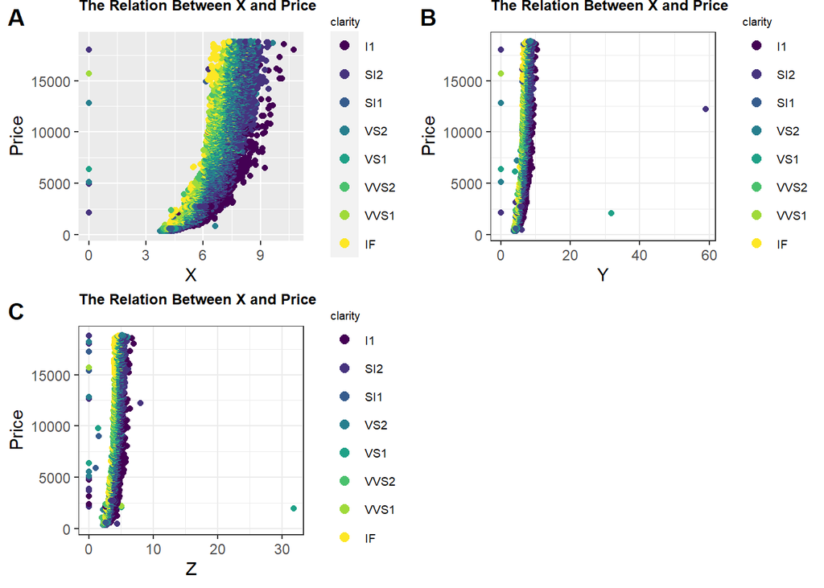

```r
plot1<- ggplot(diamonds, aes(x =x, y = price,color=clarity)) +
  geom_point()+labs(x="X", y="Price",title="The Relation Between X and Price")+theme(plot.title = element_text(size=9,face="bold",vjust=4),legend.title = element_text(size = 7),legend.text = element_text(size = 7))+
        guides(shape = guide_legend(override.aes = list(size = 1)),
               color = guide_legend(override.aes = list(size =2.5)))

plot2 <- ggplot(diamonds, aes(x = y, y=price,color=clarity)) +
  geom_point() + theme_bw() +labs(x="Y", y="Price",title="The Relation Between X and Price")+theme(plot.title = element_text(size=9,face="bold",vjust=4),legend.title = element_text(size = 7),legend.text = element_text(size = 7))+
        guides(shape = guide_legend(override.aes = list(size = 1)),
               color = guide_legend(override.aes = list(size =2.5)))


plot3 <- ggplot(diamonds, aes(x = z, y=price,color=clarity)) +
  geom_point() + theme_bw() +labs(x="Z", y="Price",title="The Relation Between X and Price")+theme(plot.title = element_text(size=9,face="bold",vjust=4),legend.title = element_text(size = 7),legend.text = element_text(size = 7))+
        guides(shape = guide_legend(override.aes = list(size = 1)),
               color = guide_legend(override.aes = list(size =2.5)))



plot_grid(plot1, plot2,plot3, labels = "AUTO")
```

## 3.5 The Proportion and Count of Cut

- The proportion of cut for different clarities and the number of cut for different diamond colors are visualized below.

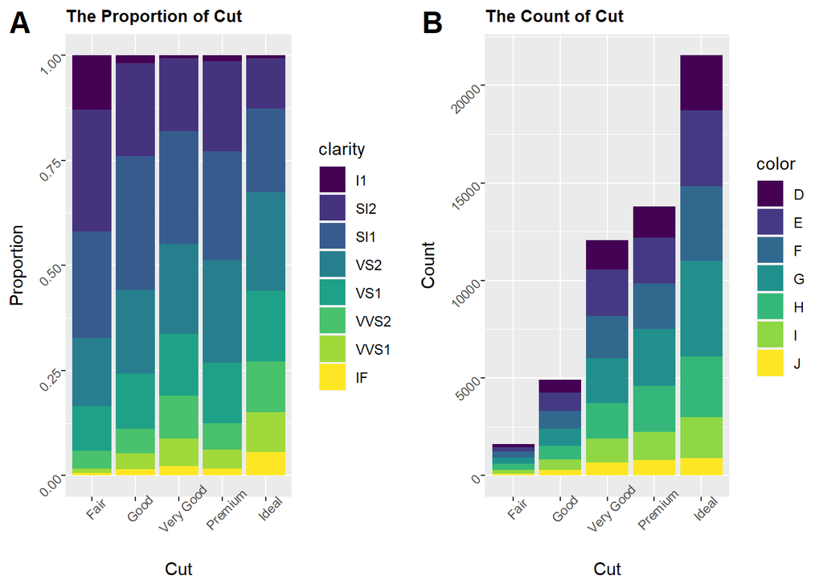

```r
plot4<-ggplot(diamonds, aes(x = cut, fill = clarity)) +
  geom_bar(position = "fill")+labs(x="Cut", y="Proportion",title="The Proportion of Cut")+theme(plot.title = element_text(size=10,face="bold"),axis.text=element_text(size=8,angle=45))

plot5<- ggplot(diamonds,aes(x=cut,fill=color))+geom_bar()+labs(x="Cut", y="Count",title="The Count of Cut")+theme(plot.title = element_text(size=10,face="bold"),axis.text=element_text(size=8,angle=45))

plot_grid(plot4, plot5 ,labels = "AUTO",label_size = 18)
```

## 3.6 The Price Grouped by Cut

- The price of diamonds grouped by cut types is visualized below.

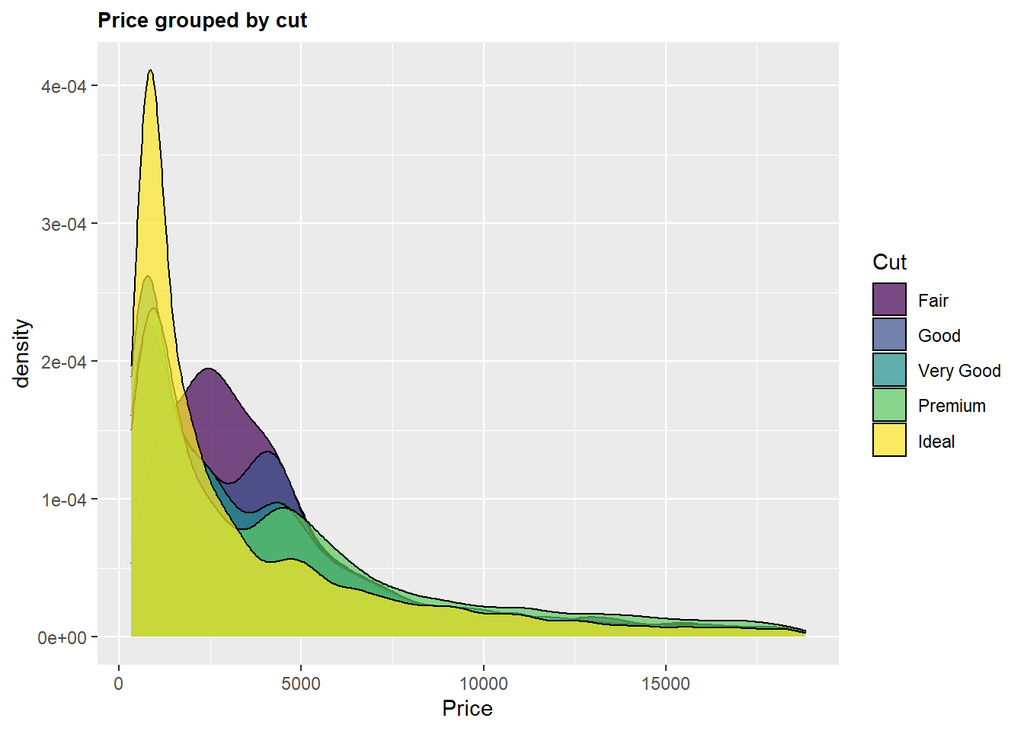

```r
ggplot(diamonds,aes(x=price))+geom_density(aes(fill=factor(cut)),alpha=0.7)+labs(title="Price grouped by cut",x="Price",fill="Cut")+theme(plot.title = element_text(size=10,face="bold"))
```

# 4 CART on Train Data

Model is implemented using `cut`,`color`,`clarity`,`depth`, and `table` features of diamonds on `diamonds_train`.

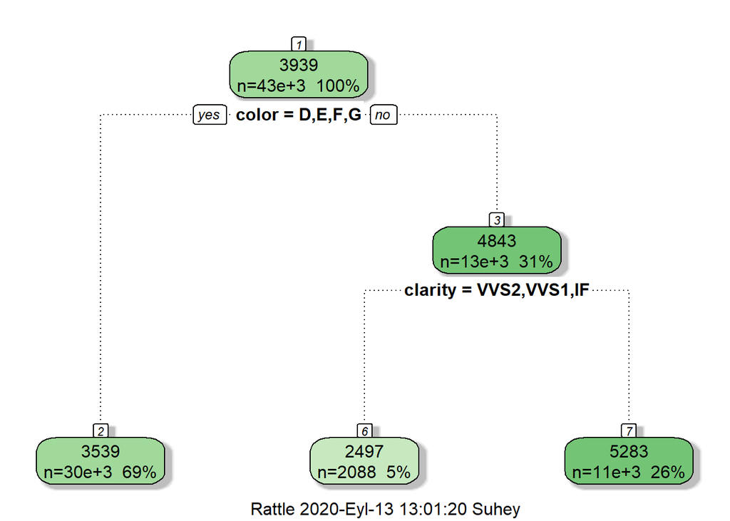

```r
diamonds_model1 <- rpart(price~cut+color+clarity+depth+table, data=diamonds_train)
fancyRpartPlot(diamonds_model1)
```

Predictions from model.

```r
prediction_train<- predict(diamonds_model1)
print(head(prediction_train))
```

```
##        1        2        3        4        5        6
## 3539.125 3539.125 5282.655 5282.655 2496.955 5282.655
```

Error for each node is calculated.Then by using objective function of CART method, minimum error of each node is taken and total error is calculated.

```r
prediction_train<-as.data.frame(prediction_train)
train_analysis<- diamonds_train%>%mutate(price,prediction_train)%>%
  select(-carat,-cut,-color,-clarity,-depth,-table,-x,-y,-z)
train_analysis<-train_analysis%>%rename(prediction=prediction_train)
train_analysis$error2<-(train_analysis$price-train_analysis$prediction)^2
train_analysis1<-train_analysis%>%group_by(prediction)%>%summarise(error=min(error2))
totalerrortrain=sum(train_analysis1$error)
totalerrortrain
```

```
## [1] 2.737126
```

R-square of model on train data.

```r
rss<-sum((train_analysis$price-train_analysis$prediction)^2)
sstol<- sum((train_analysis$price - mean(train_analysis$price))^2)
rsquared1<-(1-(rss/sstol))
rsquared1
```

```
## [1] 0.0424061
```

# 5 CART on Test Data

Same model is implemented using `cut`,`color`,`clarity`,`depth`, and `table` features of diamonds on `diamonds_test`.

```r
main_prediction<-predict(diamonds_model1,newdata =diamonds_test)
print(head(main_prediction))
```

```
##        1        2        3        4        5        6
## 3539.125 3539.125 3539.125 3539.125 3539.125 3539.125
```

Error for each node is calculated.Then by using objective function of CART method, minimum error of each node is taken and total error is calculated.

```r
main_prediction<-as.data.frame(main_prediction)
main_analysis<- diamonds_test%>% mutate(price,main_prediction)%>%
  select(-carat,-cut,-color,-clarity,-depth,-table,-x,-y,-z)
main_analysis<-main_analysis%>%rename(prediction=main_prediction)
main_analysis$error2<-(main_analysis$price-main_analysis$prediction)^2

main_analysis1<-main_analysis%>%group_by(prediction)%>%summarise(error=min(error2))
totalerrormain=sum(main_analysis1$error)
totalerrormain
```

```
## [1] 2.607395
```

R-square of model on test data.

```r
rss<-sum((main_analysis$price-main_analysis$prediction)^2)
sstol<- sum((main_analysis$price - mean(main_analysis$price))^2)
rsquared2<-(1-(rss/sstol))
rsquared2
```

```
## [1] 0.03648705
```

# 6 Improving model with Principal Component Analysis(PCA)

In order to improve current model, we can create a new model based on the components obtained from PCA.

[output not shown]

## 6.1 Correlation Matrix

The correlation matrix between variables is given below.

```r
traindata<-diamonds_train[,-c(2,3,4,7)]
testdata<-diamonds_test[,-c(2,3,4,7)]
cor(traindata)
```

```
##            carat       depth      table           x           y          z
## carat 1.00000000  0.02457809  0.1837469  0.97572577  0.94707234 0.94940570
## depth 0.02457809  1.00000000 -0.2981340 -0.02898875 -0.03291973 0.09109925
## table 0.18374688 -0.29813400  1.0000000  0.19765100  0.18453984 0.15169959
## x     0.97572577 -0.02898875  0.1976510  1.00000000  0.96904818 0.96615669
## y     0.94707234 -0.03291973  0.1845398  0.96904818  1.00000000 0.94323399
## z     0.94940570  0.09109925  0.1516996  0.96615669  0.94323399 1.00000000
```

The components of PCA and how much of the variation in data can be explained by components are given below.

```r
pca_train<-princomp(as.matrix(traindata),cor=T)
pca_test<-princomp(as.matrix(testdata),cor=T)
summary(pca_train,loadings=TRUE)
```

```
## Importance of components:
##                          Comp.1    Comp.2    Comp.3    Comp.4      Comp.5
## Standard deviation     1.979800 1.1336225 0.8255050 0.2273068 0.218071172
## Proportion of Variance 0.653268 0.2141833 0.1135764 0.0086114 0.007925839
## Cumulative Proportion  0.653268 0.8674513 0.9810277 0.9896391 0.997564967
##                             Comp.6
## Standard deviation     0.120872645
## Proportion of Variance 0.002435033
## Cumulative Proportion  1.000000000
##
## Loadings:
##       Comp.1 Comp.2 Comp.3 Comp.4 Comp.5 Comp.6
## carat  0.496                0.638  0.442  0.385
## depth         0.734 -0.671
## table  0.122 -0.669 -0.733
## x      0.501                0.114        -0.855
## y      0.494               -0.760  0.361  0.201
## z      0.493  0.103               -0.817  0.279
```

As you can clearly see, the first 2 PC is responsible for 86.7% of the variation. First PC considers carat,table, x, y and z as positive effects, second PC is highly affected by depth and considers table as a negative effect and z as a positive effect. With the third PC, 98.1% of the variation is explained.

## 6.2 Visualizaton of PCA

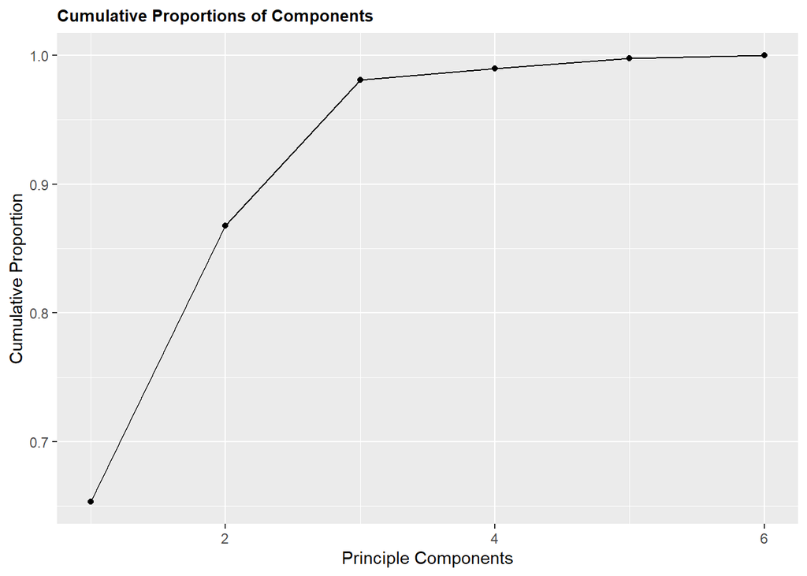

```r
ggplot(data.frame(pc=1:6,cum_var=c(0.653268,0.8674513,0.9810277,0.9896391,0.997564967,1.00000000)),aes(x=pc,y=cum_var)) + geom_point() + geom_line()+
  labs(y="Cumulative Proportion",x="Principle Components",title="Cumulative Proportions of Components")+theme(plot.title = element_text(size=10,face="bold"))
```

# 7 Model with PCA

By using components of PCA, a PCA model is created and implemented on `pca_traindata`.

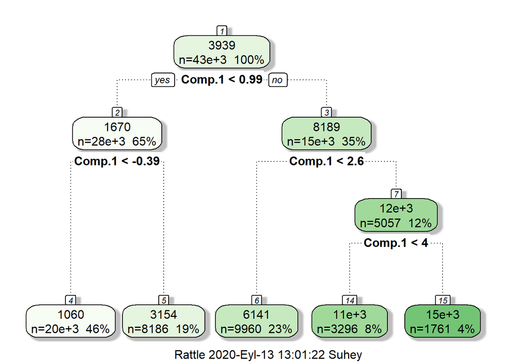

```r
pca_traindata<-cbind(diamonds_train,pca_train$scores[,1:3])
pca_testdata<-cbind(diamonds_test,pca_test$scores[,1:3])
model<- rpart(price ~ Comp.1 + Comp.2+Comp.3, data=pca_traindata)
fancyRpartPlot(model)
```

```r
main_predictionpca<-predict(model,newdata =pca_testdata)
```

You can see predictions from PCA model below.

```r
print(head(main_predictionpca))
```

```
##         1         2         3         4         5         6
## 10838.441  1060.285  6141.157  6141.157  3154.266  3154.266
```

Error for each node is calculated. Then by using objective function of CART method, minimum error of each node is taken and total error is calculated.

```r
main_predictionpca<-as.data.frame(main_predictionpca)
main_analysispca<- pca_testdata%>% mutate(price,main_predictionpca)%>%
  select(-carat,-cut,-color,-clarity,-depth,-table,-x,-y,-z,-Comp.1,-Comp.2,-Comp.3)
main_analysispca$error2<-(main_analysispca$price-main_analysispca$main_predictionpca)^2

main_analysis3<-main_analysispca%>%group_by(main_predictionpca)%>%summarise(error=min(error2))
totalerrormain=sum(main_analysis3$error)
totalerrormain
```

```
## [1] 158.2983
```

R-square of PCA model.

```r
rss<-sum((main_analysispca$price-main_analysispca$main_predictionpca)^2)
sstol<- sum((main_analysispca$price - mean(main_analysispca$price))^2)
rsquared3<-(1-(rss/sstol))
rsquared3
```

```
## [1] 0.8451937
```

# 8 Reference

- [Data Visualization](https://www.datanovia.com/en/blog/ggplot-colors-best-tricks-you-will-love/#:~:text=Change%20ggplot%20colors%20by%20assigning,or%20to%20the%20fill%20arguments.)
- [R-Graph-Gallery](https://www.r-graph-gallery.com/ggplot2-package.html)
- [Lecture Notes](https://mef-bda503.github.io/archive/fall17/files/intro_to_ml_2.html)
- [Lecture Notes](https://mef-bda503.github.io/archive/fall17/files/intro_to_ml.html)
- [Price Grouped by Cut Plot](https://www.kaggle.com/devisangeetha/data-visualization)